# Intro to DS Final Project

# Is my music taste bad?

### *An exploratory data analysis and comparison of the most popular songs trending currently to my top songs from 2017-2021 by year*

## Introduction

Music is one of the greatest forms of self-expression. You can learn a lot about a person based on their favorite songs and artists.

This made me wonder, what does my music taste say about me – and is it objectively good or bad (in comparison to popular music). Personally, I change up what I listen to based on the year.

The data for this analysis was collected using the Spotify API for the “Top Songs - USA” playlist as well as my personal Spotify Wrapped playlists from 2017, 2018, 2019, and 2020. To incorporate my current music taste as of 2021, I complied 100 songs that I have been listening to so far this year.

## Theory

The goal of this exploratory analysis is to see how my personal music compares to what is popular using the Spotify API data. I believe that my music taste is… interesting. I will be looking at each factor provided by the datasets, finding mean values for each, and then comparing to my music by year. As my music taste varies drastically between years, I have classified each year into a genre, vibe, and my most listened-to artist. Does emo Ahna have the best taste? Pop Ahna? Rap Ahna? Let’s find out.

### Classification of the “vibe” for each year

| Year | Genre | Vibes | Top Artist |
| --- | --- | --- | --- |
| 2017 | Alt-Rock | Emo | Bring Me The Horizon |
| 2018 | Happy-Pop | Happy | AJR |
| 2019 | Emo-Rap | Questionable | Juice Wrld |
| 2020 | Electro-Pop | High-Energy | Quinn XCII |
| 2021 | Chill-Pop | Vibey | Dominic Fike |

## Prerequisites

Load the required packages:

```r
library(tidyverse)
library(dplyr)
library(ggplot2)
library(scales)
library(ggridges)
```

## Dataset

Load the required raw data sets:

```r
my_2021 <- readRDS("ahna_2021.RDS")
my_2020 <- readRDS("ahna_2020.RDS")
my_2019 <- readRDS("ahna_2019.RDS")
my_2018 <- readRDS("ahna_2018.RDS")
my_2017 <- readRDS("ahna_2017.RDS")
trending <- readRDS("ahna_trending.RDS")
```

Each data set has the following parameters:

| Field | Description | Scale |
| --- | --- | --- |
| danceability | suitability for dancing, combination of tempo, beat strength, and rhythm stability | 0:1 |
| energy | measure of intensity and activity | 0:1 |
| loudness | overall loudness, measured in decibels | -60:0 |
| speechiness | presence of spoken words in a track | 0:1 |
| acousticness | how acoustic a track is | 0:1 |
| instrumentalness | predicts vocals in a track | 0:1 |
| liveness | detects presence of an audience in a track | 0:1 |
| valence | describes the musical positiveness of a track | 0:1 |
| track.popularity | rates the overall popularity of a track | 0:100 |
| track.name | specifies the title of the track | none |

## Data Filtering

Here, I am selecting the factors I want to examine, rescaling each factor (0:100), and dropping any NA values.

*The “track.popularity” and “track.name” columns will be introduced in the Conclusion section.*

```r
new_2021 <- my_2021 %>%
  mutate(
    danceability = rescale(my_2021$danceability, to = c(0,100)),
    energy = rescale(my_2021$energy, to = c(0,100)),
    loudness = rescale(my_2021$loudness, to = c(0,100)),
    speechiness = rescale(my_2021$speechiness, to = c(0,100)),
    acousticness = rescale(my_2021$acousticness, to = c(0,100)),
    instrumentalness = rescale(my_2021$instrumentalness, to = c(0,100)),
    liveness = rescale(my_2021$liveness, to = c(0,100)),
    valence = rescale(my_2021$valence, to = c(0,100))) %>%
  select(danceability, energy, loudness, speechiness, acousticness, instrumentalness, liveness, valence, track.popularity, track.name) %>%
  drop_na()

new_2020 <- my_2020 %>%
  mutate(
    danceability = rescale(my_2020$danceability, to = c(0,100)),
    energy = rescale(my_2020$energy, to = c(0,100)),
    loudness = rescale(my_2020$loudness, to = c(0,100)),
    speechiness = rescale(my_2020$speechiness, to = c(0,100)),
    acousticness = rescale(my_2020$acousticness, to = c(0,100)),
    instrumentalness = rescale(my_2020$instrumentalness, to = c(0,100)),
    liveness = rescale(my_2020$liveness, to = c(0,100)),
    valence = rescale(my_2020$valence, to = c(0,100))) %>%
  select(danceability, energy, loudness, speechiness, acousticness, instrumentalness, liveness, valence, track.popularity, track.name) %>%
  drop_na()

new_2019 <- my_2019 %>%
  mutate(
    danceability = rescale(my_2019$danceability, to = c(0,100)),
    energy = rescale(my_2019$energy, to = c(0,100)),
    loudness = rescale(my_2019$loudness, to = c(0,100)),
    speechiness = rescale(my_2019$speechiness, to = c(0,100)),
    acousticness = rescale(my_2019$acousticness, to = c(0,100)),
    instrumentalness = rescale(my_2019$instrumentalness, to = c(0,100)),
    liveness = rescale(my_2019$liveness, to = c(0,100)),
    valence = rescale(my_2019$valence, to = c(0,100))) %>%
  select(danceability, energy, loudness, speechiness, acousticness, instrumentalness, liveness, valence, track.popularity, track.name) %>%
  drop_na()

new_2018 <- my_2018 %>%
  mutate(
    danceability = rescale(my_2018$danceability, to = c(0,100)),
    energy = rescale(my_2018$energy, to = c(0,100)),
    loudness = rescale(my_2018$loudness, to = c(0,100)),
    speechiness = rescale(my_2018$speechiness, to = c(0,100)),
    acousticness = rescale(my_2018$acousticness, to = c(0,100)),
    instrumentalness = rescale(my_2018$instrumentalness, to = c(0,100)),
    liveness = rescale(my_2018$liveness, to = c(0,100)),
    valence = rescale(my_2018$valence, to = c(0,100))) %>%
  select(danceability, energy, loudness, speechiness, acousticness, instrumentalness, liveness, valence, track.popularity, track.name) %>%
  drop_na()

new_2017 <- my_2017 %>%
  mutate(
    danceability = rescale(my_2017$danceability, to = c(0,100)),
    energy = rescale(my_2017$energy, to = c(0,100)),
    loudness = rescale(my_2017$loudness, to = c(0,100)),
    speechiness = rescale(my_2017$speechiness, to = c(0,100)),
    acousticness = rescale(my_2017$acousticness, to = c(0,100)),
    instrumentalness = rescale(my_2017$instrumentalness, to = c(0,100)),
    liveness = rescale(my_2017$liveness, to = c(0,100)),
    valence = rescale(my_2017$valence, to = c(0,100))) %>%
  select(danceability, energy, loudness, speechiness, acousticness, instrumentalness, liveness, valence, track.popularity, track.name) %>%
  drop_na()

new_trending <- trending %>%
  mutate(
    danceability = rescale(trending$danceability, to = c(0,100)),
    energy = rescale(trending$energy, to = c(0,100)),
    loudness = rescale(trending$loudness, to = c(0,100)),
    speechiness = rescale(trending$speechiness, to = c(0,100)),
    acousticness = rescale(trending$acousticness, to = c(0,100)),
    instrumentalness = rescale(trending$instrumentalness, to = c(0,100)),
    liveness = rescale(trending$liveness, to = c(0,100)),
    valence = rescale(trending$valence, to = c(0,100))) %>%
  select(danceability, energy, loudness, speechiness, acousticness, instrumentalness, liveness, valence, track.popularity, track.name) %>%
  drop_na()
```

## Rating Classification

While there are eight factors being analyzed for this exploration, not every one is necessarily essential to making an objectively “good” or popular song. Here, I am breaking down which factors are most important and prevalent in the trending dataframe.

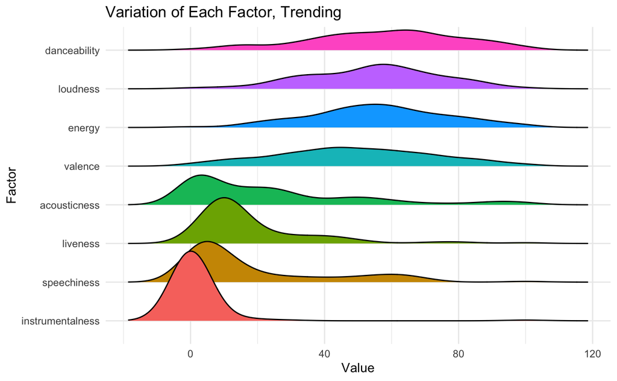

```r
new_trending %>%
  select(danceability, energy, loudness, speechiness, acousticness, instrumentalness, liveness, valence) %>%
  gather(key = "factor", value = "value") %>%
  mutate(factor = fct_reorder(factor, value)) %>%
  ggplot() +
  geom_density_ridges(aes(x = value, y = factor, fill = factor)) +
  theme_minimal() +
  labs(x = "Value", y = "Factor", title = "Variation of Each Factor, Trending") +
  theme(
    legend.position = "none")
```

The visualization above shows the variation of each factor after being rescaled. Some factors are clustered, like speechiness and instrumentalness, and others are much more spread out. To create a consistent scoring method, the outliers must be removed.

```r
outliers <- function(x) { #function to determine which values are outliers
  Q1 <- quantile(x, probs = 0.25)
  Q3 <- quantile(x, probs = 0.75)
  iqr = Q3 - Q1
  upper = Q3 + (iqr * 1.5)
  lower = Q1 - (iqr * 1.5)
  x > upper | x < lower
}

remove_outliers <- function(df, cols = names(df)) { #function to remove outliers from dataframe
  for(col in cols) {
    df <- df[!outliers(df[[col]]), ]
  }
  df
}

new_trending <- remove_outliers(new_trending, c("danceability", "energy", "loudness", "speechiness", "acousticness", "instrumentalness", "liveness", "valence"))
```

Now that the outliers have been filtered from the dataset, we can calculate the standard deviation for each factor.

```r
#taking standard deviation for each factor and making it into a wide dataframe
sd_trending <- data.frame(
  danceability = sd(new_trending[["danceability"]]),
  energy = sd(new_trending[["energy"]]),
  loudness = sd(new_trending[["loudness"]]),
  speechiness = sd(new_trending[["speechiness"]]),
  acousticness = sd(new_trending[["acousticness"]]),
  instrumentalness = sd(new_trending[["instrumentalness"]]),
  liveness = sd(new_trending[["liveness"]]),
  valence = sd(new_trending[["valence"]]))
```

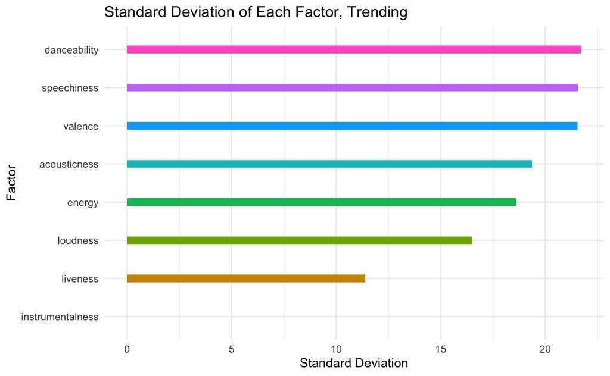

```r
sd_trending %>%
  gather(key = "factor", value = "standard_deviation") %>% #converting from wide to long format
  mutate(factor = fct_reorder(factor, standard_deviation)) %>% #reordering data by standard deviation
  ggplot(aes(x = factor, y = standard_deviation, fill = factor)) +
  geom_bar(stat = "identity", width = 0.2) +
  labs(x = "Factor", y = "Standard Deviation", title = "Standard Deviation of Each Factor, Trending") +
  coord_flip() +
  theme_minimal() +
  theme(
    legend.position = "none")
```

From the above visualization, it can be seen that after filtering instrumentalness has no standard deviation. As the scoring is based off of how many standard deviations the value is from the mean, it would be impossible to score in this category. Therefore, it will be removed from this point on.

## Scoring

What is a good score for danceability of a popular song? What about energy? Liveness? To find the rating classification, I will take the mean values and standard deviation of each factor from the trending playlist, and incorporate them into a scoring scale. The goal is to analyze each factor by year and compare it to the mean value for that particular factor from the trending playlist.

Due to the standard deviations being so high, I will divide them into subgroups to provide a more strict scale. The peak value for scoring is one-fifth of a standard deviation from the mean, and decreases as it furthers from the mean value. The absolute value of the score is taken into account for the total score. The negative values signify if the value was above or below the mean.

| Number of Standard Deviations from the Mean | Score |  |  |  |
| --- | --- | --- | --- | --- |
| 1/5 | 5 |  |  |  |
| 1/4 | 4 |  |  |  |
| 1/3 | 3 |  |  |  |
| 1/2 | 2 |  |  |  |
| 1 | 1 |  |  |  |
| >1 | 0 |  |  |  |

```r
scoring <- function(value, mean, sd_value) { #function accepts the mean value for the year's playlist, the mean value for the trending playlist, and the standard deviation for that particular factor, and returns a score from 0 to 5
  if(value >= (mean - sd_value/5) && value <= mean){
    return(-5)
  }
  else if(value >= (mean - sd_value/4) && value <= (mean - sd_value/5)){
    return(-4)
  }
  else if(value >= (mean - sd_value/3) && value <= (mean - sd_value/4)){
    return(-3)
  }
  else if(value >= (mean - sd_value/2) && value <= (mean - sd_value/3)){
    return(-2)
  }
  else if(value >= (mean - sd_value) && value <= (mean - sd_value/2)){
    return(-1)
  }
  else if(value >= mean && value <= (mean + sd_value/5)){
    return(5)
  }
  else if(value >= (mean + sd_value/5) && value <= (mean + sd_value/4)){
    return(4)
  }
  else if(value >= (mean + sd_value/4) && value <= (mean + sd_value/3)){
    return(3)
  }
  else if(value >= (mean + sd_value/3) && value <= (mean + sd_value/2)){
    return(2)
  }
  else if(value >= (mean + sd_value/2) && value <= (mean + sd_value)){
    return(1)
  }
  else {
    return(0)
  }
}

total <- function(a,b,c,d,e,f,g) { #function accepts the scores and returns the sum of their absolute values
  sum = sum(abs(a), abs(b), abs(c), abs(d), abs(e), abs(f), abs(g))
  return(sum)
}
```

## Calculations

### Example using trending playlist

Because the scoring is calculated based off of the mean values of the trending songs, the trending playlist has a perfect score of 35, as seen here:

```r
scores_trending <- c(
  a <- scoring(mean(new_trending[["danceability"]]), mean(new_trending[["danceability"]]), sd_trending[["danceability"]]),
  b <- scoring(mean(new_trending[["energy"]]), mean(new_trending[["energy"]]), sd_trending[["energy"]]),
  c <- scoring(mean(new_trending[["loudness"]]), mean(new_trending[["loudness"]]), sd_trending[["loudness"]]),
  d <- scoring(mean(new_trending[["speechiness"]]), mean(new_trending[["speechiness"]]), sd_trending[["speechiness"]]),
  e <- scoring(mean(new_trending[["acousticness"]]), mean(new_trending[["acousticness"]]), sd_trending[["acousticness"]]),
  f <- scoring(mean(new_trending[["liveness"]]), mean(new_trending[["liveness"]]), sd_trending[["liveness"]]),
  g <- scoring(mean(new_trending[["valence"]]), mean(new_trending[["valence"]]), sd_trending[["valence"]]))


total(a,b,c,d,e,f,g)
```

```
[1] 35
```

### The year of sad: 2017

```r
scores_2017 <- c( #runs each factor into the scoring algorithm and assigns the value to a vector
  a_2017 <- scoring(mean(new_2017[["danceability"]]), mean(new_trending[["danceability"]]), sd_trending[["danceability"]]),
  b_2017 <- scoring(mean(new_2017[["energy"]]), mean(new_trending[["energy"]]), sd_trending[["energy"]]),
  c_2017 <- scoring(mean(new_2017[["loudness"]]), mean(new_trending[["loudness"]]), sd_trending[["loudness"]]),
  d_2017 <- scoring(mean(new_2017[["speechiness"]]), mean(new_trending[["speechiness"]]), sd_trending[["speechiness"]]),
  e_2017 <- scoring(mean(new_2017[["acousticness"]]), mean(new_trending[["acousticness"]]), sd_trending[["acousticness"]]),
  f_2017 <- scoring(mean(new_2017[["liveness"]]), mean(new_trending[["liveness"]]), sd_trending[["liveness"]]),
  g_2017 <- scoring(mean(new_2017[["valence"]]), mean(new_trending[["valence"]]), sd_trending[["valence"]]))

sum_2017 <- total(a_2017, b_2017, c_2017, d_2017, e_2017, f_2017, g_2017)
```

### The year of happy: 2018

```r
scores_2018 <- c(
  a_2018 <- scoring(mean(new_2018[["danceability"]]), mean(new_trending[["danceability"]]), sd_trending[["danceability"]]),
  b_2018 <- scoring(mean(new_2018[["energy"]]), mean(new_trending[["energy"]]), sd_trending[["energy"]]),
  c_2018 <- scoring(mean(new_2018[["loudness"]]), mean(new_trending[["loudness"]]), sd_trending[["loudness"]]),
  d_2018 <- scoring(mean(new_2018[["speechiness"]]), mean(new_trending[["speechiness"]]), sd_trending[["speechiness"]]),
  e_2018 <- scoring(mean(new_2018[["acousticness"]]), mean(new_trending[["acousticness"]]), sd_trending[["acousticness"]]),
  f_2018 <- scoring(mean(new_2018[["liveness"]]), mean(new_trending[["liveness"]]), sd_trending[["liveness"]]),
  g_2018 <- scoring(mean(new_2018[["valence"]]), mean(new_trending[["valence"]]), sd_trending[["valence"]]))

sum_2018 <- total(a_2018, b_2018, c_2018, d_2018, e_2018, f_2018, g_2018)
```

### The year of questionable decisions: 2019

```r
scores_2019 <- c(
  a_2019 <- scoring(mean(new_2019[["danceability"]]), mean(new_trending[["danceability"]]), sd_trending[["danceability"]]),
  b_2019 <- scoring(mean(new_2019[["energy"]]), mean(new_trending[["energy"]]), sd_trending[["energy"]]),
  c_2019 <- scoring(mean(new_2019[["loudness"]]), mean(new_trending[["loudness"]]), sd_trending[["loudness"]]),
  d_2019 <- scoring(mean(new_2019[["speechiness"]]), mean(new_trending[["speechiness"]]), sd_trending[["speechiness"]]),
  e_2019 <- scoring(mean(new_2019[["acousticness"]]), mean(new_trending[["acousticness"]]), sd_trending[["acousticness"]]),
  f_2019 <- scoring(mean(new_2019[["liveness"]]), mean(new_trending[["liveness"]]), sd_trending[["liveness"]]),
  g_2019 <- scoring(mean(new_2019[["valence"]]), mean(new_trending[["valence"]]), sd_trending[["valence"]]))

sum_2019 <- total(a_2019, b_2019, c_2019, d_2019, e_2019, f_2019, g_2019)
```

### The year of chaotic energy: 2020

```r
scores_2020 <- c(
  a_2020 <- scoring(mean(new_2020[["danceability"]]), mean(new_trending[["danceability"]]), sd_trending[["danceability"]]),
  b_2020 <- scoring(mean(new_2020[["energy"]]), mean(new_trending[["energy"]]), sd_trending[["energy"]]),
  c_2020 <- scoring(mean(new_2020[["loudness"]]), mean(new_trending[["loudness"]]), sd_trending[["loudness"]]),
  d_2020 <- scoring(mean(new_2020[["speechiness"]]), mean(new_trending[["speechiness"]]), sd_trending[["speechiness"]]),
  e_2020 <- scoring(mean(new_2020[["acousticness"]]), mean(new_trending[["acousticness"]]), sd_trending[["acousticness"]]),
  f_2020 <- scoring(mean(new_2020[["liveness"]]), mean(new_trending[["liveness"]]), sd_trending[["liveness"]]),
  g_2020 <- scoring(mean(new_2020[["valence"]]), mean(new_trending[["valence"]]), sd_trending[["valence"]]))

sum_2020 <- total(a_2020, b_2020, c_2020, d_2020, e_2020, f_2020, g_2020)
```

### The year of immaculate vibes: 2021

```r
scores_2021 <- c(
  a_2021 <- scoring(mean(new_2021[["danceability"]]), mean(new_trending[["danceability"]]), sd_trending[["danceability"]]),
  b_2021 <- scoring(mean(new_2021[["energy"]]), mean(new_trending[["energy"]]), sd_trending[["energy"]]),
  c_2021 <- scoring(mean(new_2021[["loudness"]]), mean(new_trending[["loudness"]]), sd_trending[["loudness"]]),
  d_2021 <- scoring(mean(new_2021[["speechiness"]]), mean(new_trending[["speechiness"]]), sd_trending[["speechiness"]]),
  e_2021 <- scoring(mean(new_2021[["acousticness"]]), mean(new_trending[["acousticness"]]), sd_trending[["acousticness"]]),
  f_2021 <- scoring(mean(new_2021[["liveness"]]), mean(new_trending[["liveness"]]), sd_trending[["liveness"]]),
  g_2021 <- scoring(mean(new_2021[["valence"]]), mean(new_trending[["valence"]]), sd_trending[["valence"]]))

sum_2021 <- total(a_2021, b_2021, c_2021, d_2021, e_2021, f_2021, g_2021)
```

## Findings

To begin analyzing each year, I first am combining all of the scores for each factor by year into one wide dataframe.

```r
scores <- data.frame(
  factor = c("Danceability", "Energy", "Loudness", "Speechiness", "Acousticness", "Liveness", "Valence"),
  scores_2017, scores_2018, scores_2019, scores_2020, scores_2021
)
```

### The year of sad: 2017

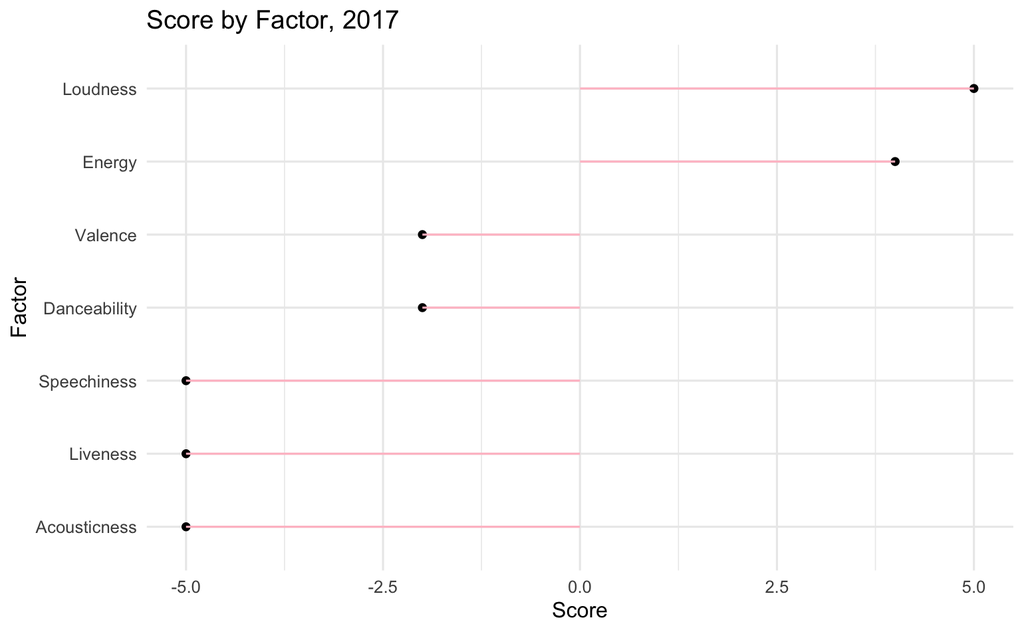

```r
scores %>%
  select(factor, scores_2017) %>%
  mutate(factor = fct_reorder(factor, scores_2017)) %>% #reordering data by score
  ggplot() +
  geom_point(aes(x = factor, y = scores_2017), color = "black") +
  geom_segment(aes(x = factor, xend = factor, y = 0, yend = scores_2017), color = "pink") +
  labs(x = "Factor", y = "Score", title = "Score by Factor, 2017") +
  coord_flip() +
  theme_minimal()
```

First is the year of sad (2017), which scored a 28 out of a possible 35. This year came in second place, and considering the songs on this particular playlist, that is very surprising. It had above average energy, and below average valence and danceability. As valence is the overall “positiveness” of a song, the low rating corresponds to the determined vibe of the playlist.

### The year of happy: 2018

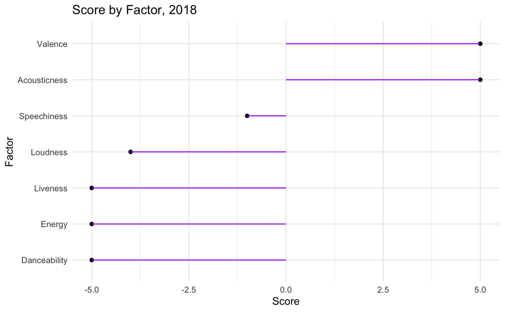

```r
scores %>%
  select(factor, scores_2018) %>%
  mutate(factor = fct_reorder(factor, scores_2018)) %>% #reordering data by score
  ggplot() +
  geom_point(aes(x = factor, y = scores_2018), color = "black") +
  geom_segment(aes(x = factor, xend = factor, y = 0, yend = scores_2018), color = "purple") +
  labs(x = "Factor", y = "Score", title = "Score by Factor, 2018") +
  coord_flip() +
  theme_minimal()
```

In first place, the year of happy (2018) scored a 30 out of the possible 35. This year received perfect scores in all categories except for two. This particular playlist was characterized by bubbly-pop music, which explains why it is lacking in speechiness and loudness. However, the rest of the factors pertaining to this playlist are right on par to what is currently popular.

### The year of questionable decisions: 2019

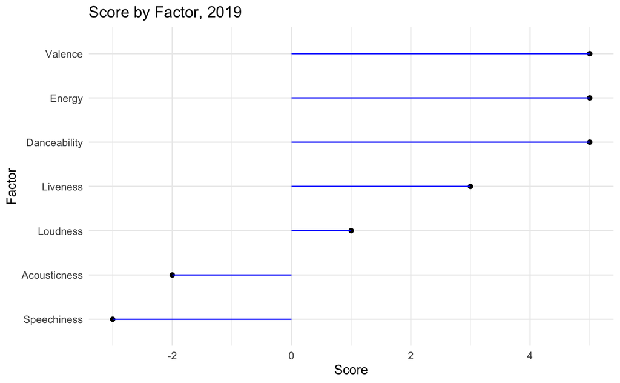

```r
scores %>%
  select(factor, scores_2019) %>%
  mutate(factor = fct_reorder(factor, scores_2019)) %>% #reordering data by score
  ggplot() +
  geom_point(aes(x = factor, y = scores_2019), color = "black") +
  geom_segment(aes(x = factor, xend = factor, y = 0, yend = scores_2019), color = "blue") +
  labs(x = "Factor", y = "Score", title = "Score by Factor, 2019") +
  coord_flip() +
  theme_minimal()
```

Surprisingly, the year of questionable decisions (2019), did not score in last place. With a score of 24 out of the possible 35, this playlist was mainly brought down by the lower-than-average acousticness and the higher-than-average loudness values. Juice WRLD would be proud.

### The year of chaotic energy: 2020

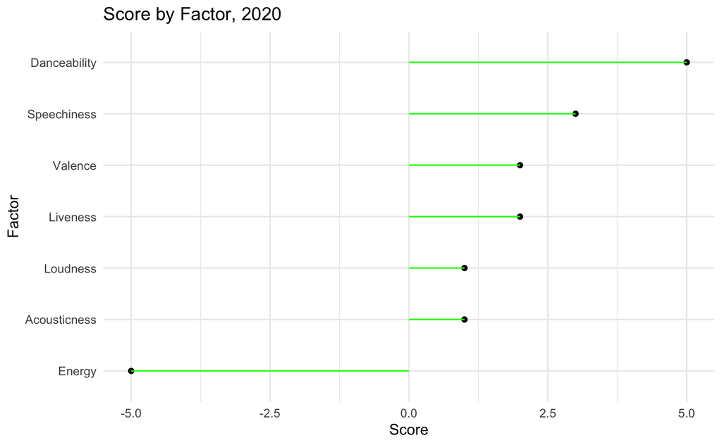

```r
scores %>%
  select(factor, scores_2020) %>%
  mutate(factor = fct_reorder(factor, scores_2020)) %>% #reordering data by score
  ggplot() +
  geom_point(aes(x = factor, y = scores_2020), color = "black") +
  geom_segment(aes(x = factor, xend = factor, y = 0, yend = scores_2020), color = "green") +
  labs(x = "Factor", y = "Score", title = "Score by Factor, 2020") +
  coord_flip() +
  theme_minimal()
```

The year of chaotic energy (2020), scored in last place at 19 out of the possible 35. While the energy and danceability of this electro-pop playlist were within 1/5 of a standard deviation from the trending-mean, every other factor brough the overall score down significantly. This playlist had above-average ratings in every category except for energy.

### The year of immaculate vibes: 2021

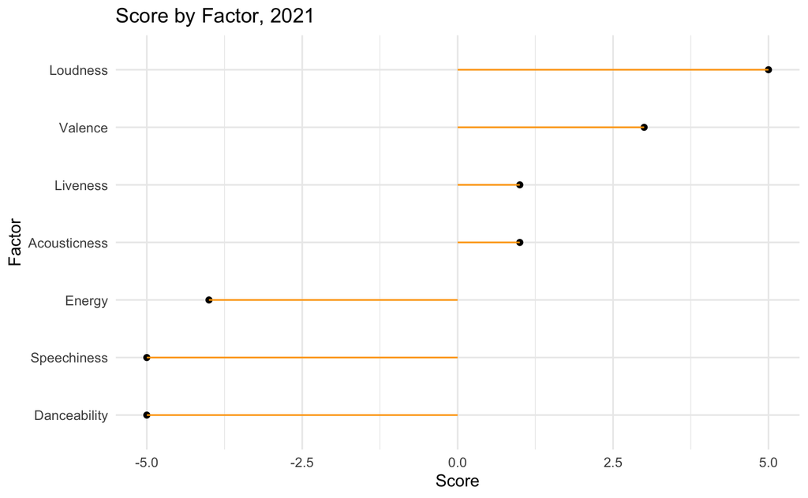

```r
scores %>%
  select(factor, scores_2021) %>%
  mutate(factor = fct_reorder(factor, scores_2021)) %>% #reordering data by score
  ggplot() +
  geom_point(aes(x = factor, y = scores_2021), color = "black") +
  geom_segment(aes(x = factor, xend = factor, y = 0, yend = scores_2021), color = "orange") +
  labs(x = "Factor", y = "Score", title = "Score by Factor, 2021") +
  coord_flip() +
  theme_minimal()
```

Finally, receiving a score of 24 is the year of immaculate vibes (2021). This playlist had above-average liveness and acousticness that was significantly distant from the mean which brought down the total score.

## Conclusion

### Relationship between each year and individual scores

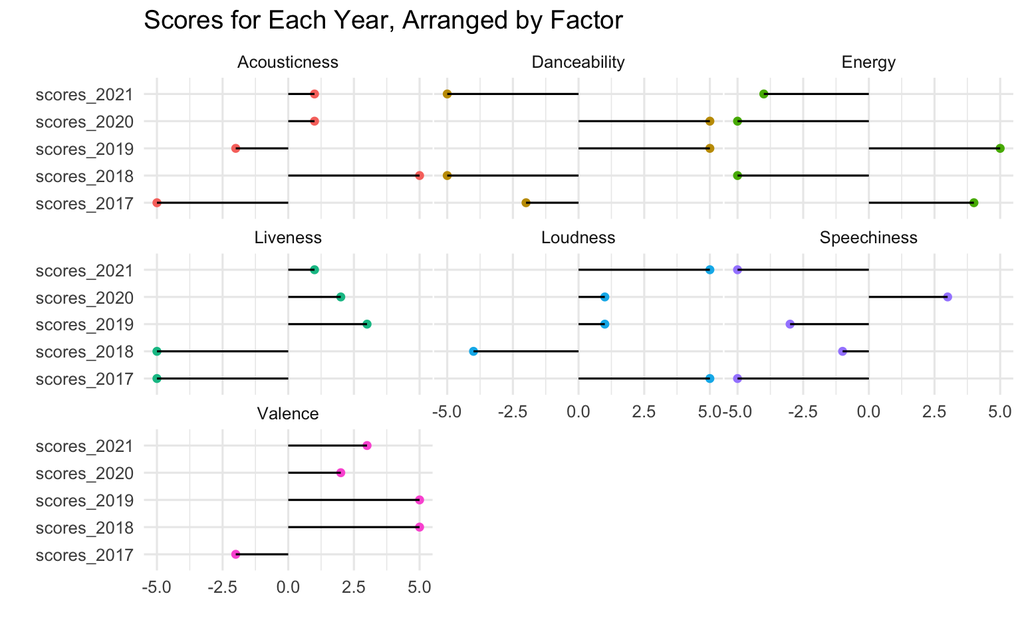

```r
scores %>%
  pivot_longer(cols = c(scores_2017, scores_2018, scores_2019, scores_2020, scores_2021), names_to = "year") %>%
  ggplot() +
  geom_point(aes(x = year, y = value, color = factor)) +
  geom_segment(aes(x = year, xend = year, y = 0, yend = value)) +
  theme_minimal() +
  labs(x = " ", y = " ", title = "Scores for Each Year, Arranged by Factor") +
  facet_wrap(~factor) +
  theme(
    legend.position = "none",
    panel.spacing = unit(0.05, "lines")
  ) +
  coord_flip()
```

```r
NA
```

In the above visualization, the most consistent factor by year was valence. This means that for every year excluding 2017, the overall “vibe” was happy and upbeat. Besides this factor, there is no correlation between years for the other factors.

### Relationship between each year and total scores

```r
sum_scores <- data.frame( #creates a dataframe for total score by year
  year = c(2017:2021),
  score = c(sum_2017, sum_2018, sum_2019, sum_2020, sum_2021)
)
```

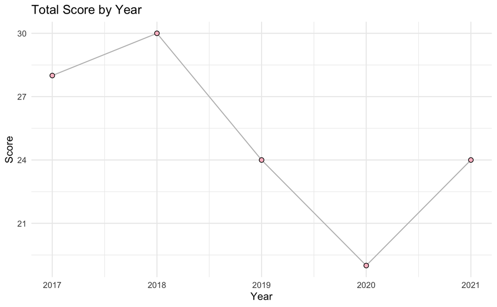

```r
sum_scores %>%
  ggplot(aes(x = year, y = score)) +
  geom_line(color = "grey") +
  geom_point(color = "black", fill = "pink", shape = 21, size = 2) +
  labs(x = "Year", y = "Score", title = "Total Score by Year") +
  theme_minimal()
```

### Relationship Between Popularity Rating and Total Score

Each song in every playlist has a popularity rating assigned to it through the Spotify API. Which year’s playlist is the most popular according to the Spotify API, and does this have anything to do with the final scores in relation to the trending playlist?

```r
popularity_rating <- data.frame( #takes mean popularity score by year and compiles it into a dataframe
  year = c(2017:2021),
  rating = c(
    mean(new_2017[["track.popularity"]]),
    mean(new_2018[["track.popularity"]]),
    mean(new_2019[["track.popularity"]]),
    mean(new_2020[["track.popularity"]]),
    mean(new_2021[["track.popularity"]])
  )
)
```

```r
sum_scaled <- data.frame( #rescales the sum_scores dataframe from 0 to 100 for ease of comparison
  year = c(2017:2021),
  score = rescale(sum_scores$score, to = c(0, 100)))
```

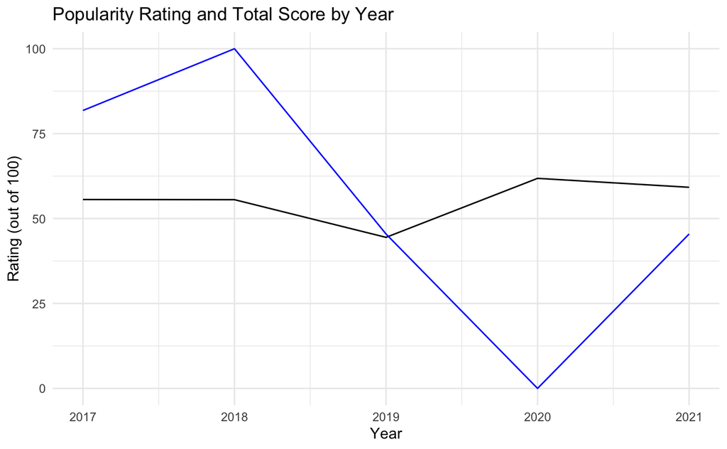

```r
ggplot() +
  geom_line(data = popularity_rating, aes(x = year, y = rating), color = "black") +
  geom_line(data = sum_scaled, aes(x = year, y = score), color = "blue") +
  theme_minimal() +
  labs(x = "Year", y = "Rating (out of 100)", title = "Popularity Rating and Total Score by Year")
```

## For fun

### What is the best song on all of my playlists?

```r
my_songs <- merge(merge(merge(merge(new_2017, new_2018, all = T), #merging each year into one large dataframe
                                    new_2019, all = T),
                                    new_2020, all = T),
                                    new_2021, all = T)

my_songs <- my_songs %>% #mutating the above dataframe to include columns with each factor's respective score
  mutate(
    score_danceability = mapply(scoring, my_songs$danceability, mean(new_trending$danceability), sd_trending$danceability),
    score_energy = mapply(scoring, my_songs$energy, mean(new_trending$energy), sd_trending$energy),
    score_loudness = mapply(scoring, my_songs$loudness, mean(new_trending$loudness), sd_trending$loudness),
    score_speechiness = mapply(scoring, my_songs$speechiness, mean(new_trending$speechiness), sd_trending$speechiness),
    score_acousticness = mapply(scoring, my_songs$acousticness, mean(new_trending$acousticness), sd_trending$acousticness),
    score_instrumentalness = mapply(scoring, my_songs$instrumentalness, mean(new_trending$instrumentalness), sd_trending$instrumentalness),
    score_liveness = mapply(scoring, my_songs$liveness, mean(new_trending$liveness), sd_trending$liveness),
    score_valence = mapply(scoring, my_songs$valence, mean(new_trending$valence), sd_trending$valence),
    final_score = mapply(total, score_danceability, score_energy, score_loudness, score_speechiness, score_acousticness, score_liveness, score_valence))

my_songs %>%
  arrange(desc(final_score)) %>% #arranging the dataframe by descending final score
  select(track.name, final_score) %>%
  head(2)
```

|  | track.name | final_score |
| --- | --- | --- |
| 1 | Something Just Like This | 25 |
| 2 | Let You Down | 25 |

```r
NA
```

The highest score for an individual song out of all of my playlists was a 25. There was a tie for this top spot between the songs “Something Like This” and “Let You Down”.

## Popularity vs Score by Song

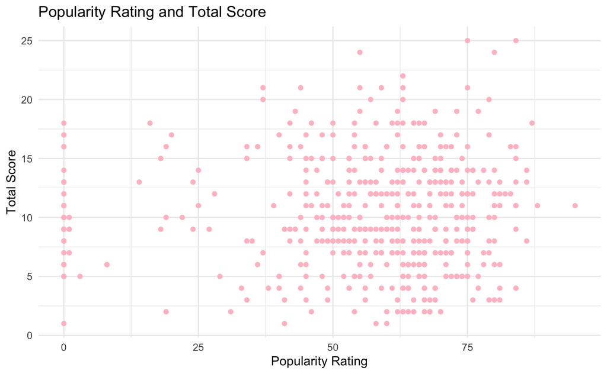

```r
my_songs %>%
  ggplot() +
  geom_point(aes(x = track.popularity, y = final_score), color = "pink") +
  theme_minimal() +
  labs(x = "Popularity Rating", y = "Total Score", title = "Popularity Rating and Total Score")
```

There is no trend between a track’s popularity and how well it scores on the scale I have created. This is likely because the track.popularity parameter does not take into account any of the audio features of the song (only the actual popularity of that song), while my scale depends solely on audio features of songs that are already popular.